# Urbanization Final Project

Emmet Doyle

2024-12-14

**Introduction** This project examines the relationship between urbanization and income distribution across U.S. states, including Washington, D.C., and Puerto Rico. By analyzing how urbanization levels influence average household income, this study seeks to uncover trends and disparities across different regions.

The analysis is built upon datasets sourced from credible repositories:

Urbanization Data: Derived from the “urbanization-census-tract.csv” file, this dataset provides urbanization indices aggregated at the census tract level. It highlights the extent of urban development across regions.

Income Distribution Data: This dataset details household income distributions across various income brackets for each state. It facilitates an understanding of economic disparities.

**Objectives** Urbanization Trends: Summarize urbanization levels by state and categorize them into levels of development. Income Correlations: Explore how urbanization indices correlate with average household income across regions. Regional Insights: Identify patterns specific to individual states, Washington, D.C., and Puerto Rico, highlighting regional differences in urbanization and income. The analysis incorporates statistical summaries, visualizations, and regression modeling to uncover meaningful patterns, aiding in the understanding of urbanization’s impact on economic outcomes.*

```r
# Install and load necessary libraries

library(dplyr)
library(readxl)
library(sf)
```

```r
library(ggplot2)
library(readr)
urbanization_census_tract <- read.csv("urbanization-census-tract.csv")

# View the structure of the dataset
str(urbanization_census_tract)
```

```
## 'data.frame':    73280 obs. of  8 variables:
##  $ statefips      : int  1 1 1 1 1 1 1 1 1 1 ...
##  $ state          : chr  "Alabama" "Alabama" "Alabama" "Alabama" ...
##  $ gisjoin        : chr  "G0100010020100" "G0100010020200" "G0100010020300" "G0100010020400" ...
##  $ lat_tract      : num  32.5 32.5 32.5 32.5 32.5 ...
##  $ long_tract     : num  -86.5 -86.5 -86.5 -86.4 -86.4 ...
##  $ population     : int  1845 2172 3385 4267 9965 3620 3420 2913 11333 6167 ...
##  $ adj_radiuspop_5: num  44076 43008 38987 43131 43131 ...
##  $ urbanindex     : num  10.7 10.7 10.6 10.7 10.7 ...
```

```r
# Display the first few rows
head(urbanization_census_tract)
```

```
##   statefips   state        gisjoin lat_tract long_tract population
## 1         1 Alabama G0100010020100  32.47718  -86.49007       1845
## 2         1 Alabama G0100010020200  32.47425  -86.47337       2172
## 3         1 Alabama G0100010020300  32.47543  -86.46019       3385
## 4         1 Alabama G0100010020400  32.47200  -86.44363       4267
## 5         1 Alabama G0100010020500  32.45883  -86.42266       9965
## 6         1 Alabama G0100010020600  32.44254  -86.47874       3620
##   adj_radiuspop_5 urbanindex
## 1           44076   10.69367
## 2           43008   10.66914
## 3           38987   10.57098
## 4           43131   10.67200
## 5           43131   10.67200
## 6           34588   10.45126
```

```r
# Summary statistics
summary(urbanization_census_tract)
```

```
##    statefips        state             gisjoin            lat_tract
##  Min.   : 1.00   Length:73280       Length:73280       Min.   :17.95
##  1st Qu.:13.00   Class :character   Class :character   1st Qu.:33.92
##  Median :28.00   Mode  :character   Mode  :character   Median :38.72
##  Mean   :28.27                                         Mean   :37.49
##  3rd Qu.:42.00                                         3rd Qu.:41.35
##  Max.   :72.00                                         Max.   :71.23
##    long_tract        population    adj_radiuspop_5     urbanindex
##  Min.   :-166.87   Min.   :    2   Min.   :      1   Min.   :-0.2978
##  1st Qu.: -97.76   1st Qu.: 2941   1st Qu.:  22480   1st Qu.:10.0204
##  Median : -86.65   Median : 4126   Median : 110956   Median :11.6169
##  Mean   : -91.29   Mean   : 4426   Mean   : 230129   Mean   :11.0420
##  3rd Qu.: -79.80   3rd Qu.: 5523   3rd Qu.: 258050   3rd Qu.:12.4609
##  Max.   : -65.29   Max.   :65528   Max.   :3259978   Max.   :14.9972
```

```r
colnames(urbanization_census_tract)
```

```
## [1] "statefips"       "state"           "gisjoin"         "lat_tract"
## [5] "long_tract"      "population"      "adj_radiuspop_5" "urbanindex"
```

State fips and state are going to be important when combining different datasets into one. The next step is to observe the data by average maximum and minimum. We also need to look at differing levels of urbanization as it will be important to understand later information.

```r
# Summarize urbanization index by state
urban_by_state <- urbanization_census_tract %>%
  group_by(state) %>%
  summarise(
    mean_urbanindex = mean(urbanindex, na.rm = TRUE),
    max_urbanindex = max(urbanindex, na.rm = TRUE),
    min_urbanindex = min(urbanindex, na.rm = TRUE),
    total_population = sum(population, na.rm = TRUE)
  )

# View top states with highest average urbanization
urban_by_state %>% arrange(desc(mean_urbanindex)) %>% head(10)
```

```
## # A tibble: 10 × 5
##    state          mean_urbanindex max_urbanindex min_urbanindex total_population
##    <chr>                    <dbl>          <dbl>          <dbl>            <int>
##  1 District of C…            13.4           13.6          12.9            672391
##  2 New York                  12.5           15.0           5.34         19740921
##  3 New Jersey                12.2           14.6           6.75          8960161
##  4 California                12.2           14.1           3.13         38977899
##  5 Massachusetts             11.9           13.8           7.14          6789319
##  6 Maryland                  11.8           13.6           6.48          5996079
##  7 Rhode Island              11.7           12.9           5.85          1056138
##  8 Nevada                    11.7           13.2           3.35          2887725
##  9 Puerto Rico               11.7           13.2           3.93          3468963
## 10 Illinois                  11.6           14.1           5.87         12854526
```

```r
# View states with the lowest average urbanization
urban_by_state %>% arrange(mean_urbanindex) %>% head(10)
```

```
## # A tibble: 10 × 5
##    state        mean_urbanindex max_urbanindex min_urbanindex total_population
##    <chr>                  <dbl>          <dbl>          <dbl>            <int>
##  1 Montana                 7.89           11.6          3.38           1029862
##  2 Alaska                  7.99           12.3         -0.298           730436
##  3 North Dakota            8.20           12.0          4.22            745475
##  4 Wyoming                 8.22           11.3          3.52            583200
##  5 South Dakota            8.26           12.0          3.75            841153
##  6 Vermont                 8.68           11.5          6.67            624636
##  7 Maine                   8.84           11.7          4.00           1330158
##  8 Mississippi             9.02           11.8          5.70           2986220
##  9 Arkansas                9.11           12.0          5.71           2977944
## 10 Idaho                   9.12           12.3          3.64           1657375
```

A problem encountered is that there are observations such as The District of Columbia in the dataset, we will include them for sake of having the information, and the data is relavant to United States data. In this step I also sorted some of the most important information such as the minimums and maximums and the average with the total populations of the states observed.

```r
# Tracts with the highest and lowest urbanization index
highest_urbanized_tracts <- urbanization_census_tract %>% arrange(desc(urbanindex)) %>% head(10)
lowest_urbanized_tracts <- urbanization_census_tract %>% arrange(urbanindex) %>% head(10)

# View results
highest_urbanized_tracts
```

```
##    statefips    state        gisjoin lat_tract long_tract population
## 1         36 New York G3600470044700  40.70667  -73.92265       2496
## 2         36 New York G3600470045300  40.70659  -73.92895       2513
## 3         36 New York G3600470042700  40.70369  -73.92719       5303
## 4         36 New York G3600470044900  40.71784  -73.93098       3034
## 5         36 New York G3600470059100  40.72355  -73.94292       3998
## 6         36 New York G3600470048500  40.70784  -73.93635       2802
## 7         36 New York G3600470048100  40.71386  -73.93850       3050
## 8         36 New York G3600470047700  40.71824  -73.94215       3816
## 9         36 New York G3600470044500  40.70499  -73.91971       5066
## 10        36 New York G3600470042900  40.70180  -73.92345       5327
##    adj_radiuspop_5 urbanindex
## 1          3259978   14.99723
## 2          3252780   14.99502
## 3          3247475   14.99339
## 4          3227203   14.98713
## 5          3219800   14.98483
## 6          3217140   14.98400
## 7          3215221   14.98341
## 8          3212470   14.98255
## 9          3204718   14.98013
## 10         3194459   14.97693
```

```r
lowest_urbanized_tracts
```

```
##    statefips  state        gisjoin lat_tract long_tract population
## 1          2 Alaska G0200160000100  52.51656  -87.62968        975
## 2          2 Alaska G0200130000100  55.36356 -161.99370       3338
## 3          2 Alaska G0200160000200  53.67216 -166.86780       4809
## 4          2 Alaska G0201850000100  71.22942 -156.73980       4444
## 5          2 Alaska G0202900000300  65.33978 -156.23380       1823
## 6          2 Alaska G0202820000100  59.89281 -140.36700        682
## 7          2 Alaska G0202900000100  66.85707 -144.45050       1224
## 8          2 Alaska G0202900000200  66.04549 -150.87210       1378
## 9          2 Alaska G0201850000200  69.27401 -153.58560       2530
## 10         2 Alaska G0201850000300  70.08279 -149.67560       2783
##    adj_radiuspop_5 urbanindex
## 1        0.7424737 -0.2977678
## 2        1.4473780  0.3697534
## 3        1.4473780  0.3697534
## 4        3.1706760  1.1539450
## 5        3.1966990  1.1621190
## 6        3.2976790  1.1932190
## 7        3.7461820  1.3207370
## 8        5.2685630  1.6617580
## 9        6.2946180  1.8396950
## 10       6.2946180  1.8396950
```

This stop helps understand that the most urbanized areas are in New York, while the least urbanized areas in the dataset are observed (expectedly) in Alaska.

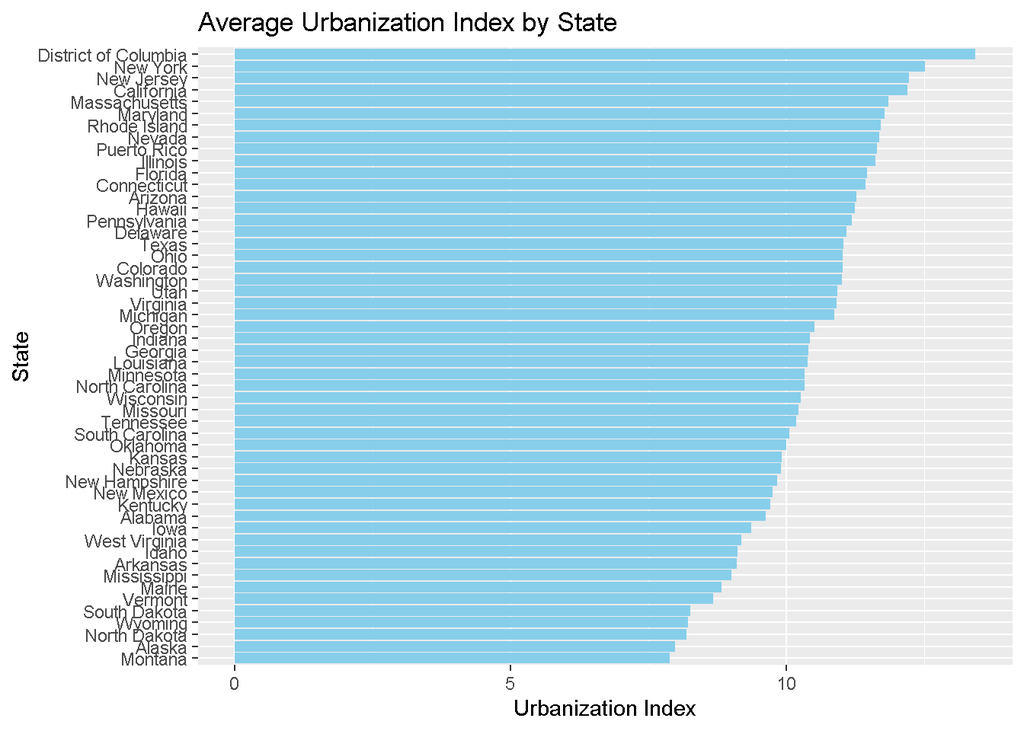

```r
# Bar plot of average urbanization by state
ggplot(urban_by_state, aes(x = reorder(state, mean_urbanindex), y = mean_urbanindex)) +
  geom_bar(stat = "identity", fill = "skyblue") +
  labs(title = "Average Urbanization Index by State", x = "State", y = "Urbanization Index") +
  coord_flip()
```

This shows the graphs for the levels of average urbanization, seeing how many observations are on a single graph it is appropriate to create graphs that can read the information in a more effective way.

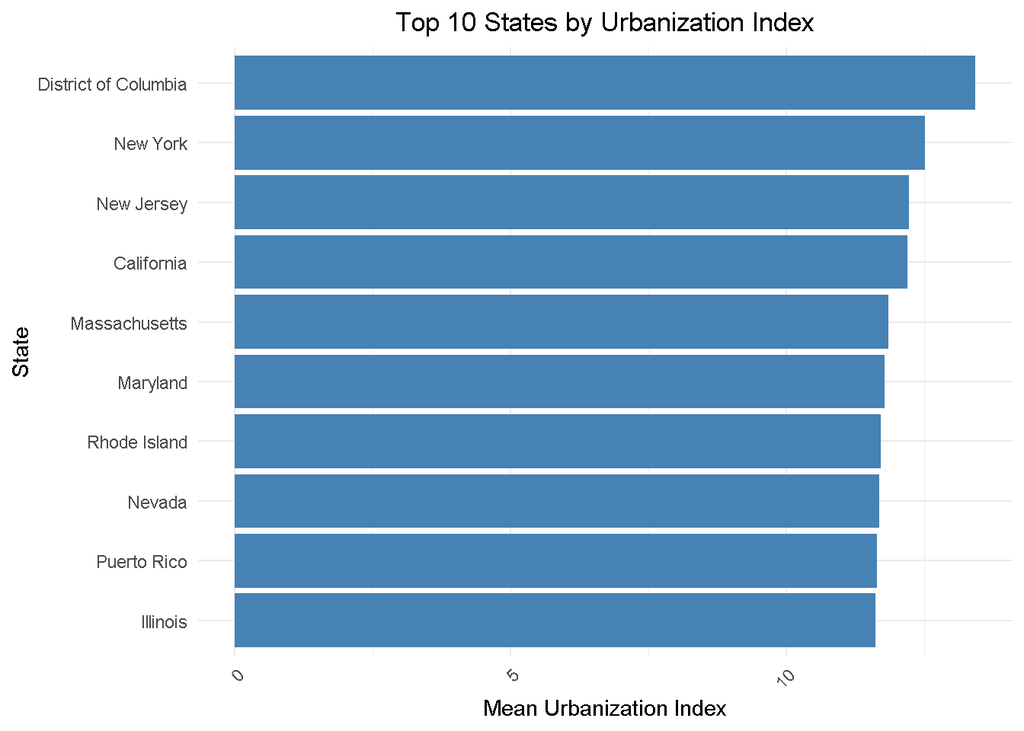

```r
# Make the graphs easier to see

# Top 10 states by urbanization index
top_urban_states <- urban_by_state %>%
  arrange(desc(mean_urbanindex)) %>%
  head(10)

# Bottom 10 states by urbanization index
bottom_urban_states <- urban_by_state %>%
  arrange(mean_urbanindex) %>%
  head(10)


ggplot(top_urban_states, aes(x = reorder(state, mean_urbanindex), y = mean_urbanindex)) +
  geom_bar(stat = "identity", fill = "steelblue") +
  labs(
    title = "Top 10 States by Urbanization Index",
    x = "State",
    y = "Mean Urbanization Index"
  ) +
  coord_flip() +
  theme_minimal() +
  theme(
    plot.title = element_text(hjust = 0.5),
    axis.text.x = element_text(angle = 45, hjust = 1)
  )
```

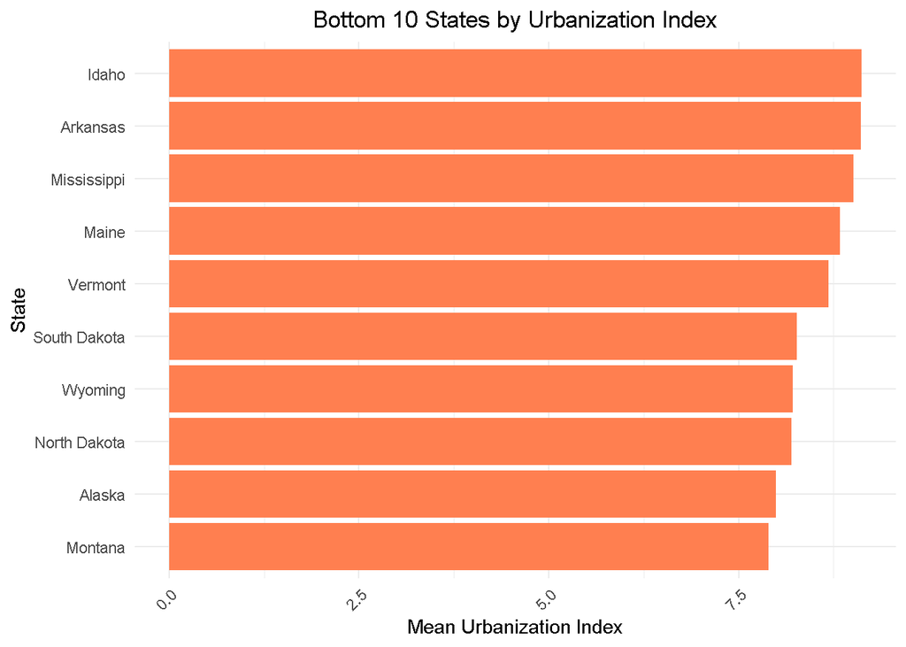

```r
ggplot(bottom_urban_states, aes(x = reorder(state, mean_urbanindex), y = mean_urbanindex)) +
  geom_bar(stat = "identity", fill = "coral") +
  labs(
    title = "Bottom 10 States by Urbanization Index",
    x = "State",
    y = "Mean Urbanization Index"
  ) +
  coord_flip() +
  theme_minimal() +
  theme(
    plot.title = element_text(hjust = 0.5),
    axis.text.x = element_text(angle = 45, hjust = 1)
  )
```

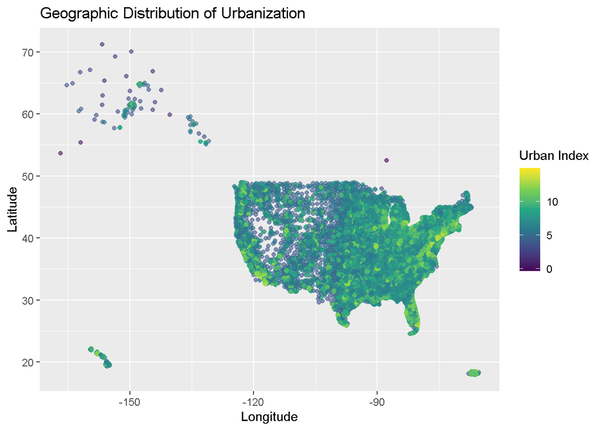

```r
ggplot(urbanization_census_tract, aes(x = long_tract, y = lat_tract, color = urbanindex)) +
  geom_point(alpha = 0.6) +
  scale_color_viridis_c() +
  labs(title = "Geographic Distribution of Urbanization", x = "Longitude", y = "Latitude", color = "Urban Index")
```

```r
urban_by_state %>%
  arrange(desc(mean_urbanindex)) %>%
  head(5)
```

```
## # A tibble: 5 × 5
##   state           mean_urbanindex max_urbanindex min_urbanindex total_population
##   <chr>                     <dbl>          <dbl>          <dbl>            <int>
## 1 District of Co…            13.4           13.6          12.9            672391
## 2 New York                   12.5           15.0           5.34         19740921
## 3 New Jersey                 12.2           14.6           6.75          8960161
## 4 California                 12.2           14.1           3.13         38977899
## 5 Massachusetts              11.9           13.8           7.14          6789319
```

```r
urban_by_state %>%
  arrange(mean_urbanindex) %>%
  head(5)
```

```
## # A tibble: 5 × 5
##   state        mean_urbanindex max_urbanindex min_urbanindex total_population
##   <chr>                  <dbl>          <dbl>          <dbl>            <int>
## 1 Montana                 7.89           11.6          3.38           1029862
## 2 Alaska                  7.99           12.3         -0.298           730436
## 3 North Dakota            8.20           12.0          4.22            745475
## 4 Wyoming                 8.22           11.3          3.52            583200
## 5 South Dakota            8.26           12.0          3.75            841153
```

```r
# Tracts with the highest urbanization
urbanization_census_tract %>%
  filter(urbanindex == max(urbanindex, na.rm = TRUE))
```

```
##   statefips    state        gisjoin lat_tract long_tract population
## 1        36 New York G3600470044700  40.70667  -73.92265       2496
##   adj_radiuspop_5 urbanindex
## 1         3259978   14.99723
```

```r
# Tracts with the lowest urbanization
urbanization_census_tract %>%
  filter(urbanindex == min(urbanindex, na.rm = TRUE))
```

```
##   statefips  state        gisjoin lat_tract long_tract population
## 1         2 Alaska G0200160000100  52.51656  -87.62968        975
##   adj_radiuspop_5 urbanindex
## 1       0.7424737 -0.2977678
```

```r
# Look at income in the states relative to their urban density

census_data <- read.csv("ACSST1Y2023.S1901-2024-12-15T033616.csv")

urbanization_data <- read.csv("urbanization-census-tract.csv")


# Load the dataset
file_path <- "ACSST1Y2023.S1901-2024-12-15T033616.csv"
data <- read.csv(file_path, check.names = FALSE)

library(tidyr)
# Reshape data to a tidy format
tidy_data <- data %>%
  pivot_longer(
    cols = -`Label (Grouping)`,          # Keep the "Label (Grouping)" column
    names_to = c("State", "Metric"),     # Split column names into State and Metric
    names_sep = "!!",                    # Separator used in the column names
    values_to = "Value"
  )
# View the first few rows of the tidy dataset
head(tidy_data)
```

```
## # A tibble: 6 × 4
##   `Label (Grouping)` State   Metric                  Value
##   <chr>              <chr>   <chr>                   <chr>
## 1 Total              Alabama Households              2,051,545
## 2 Total              Alabama Households              ±10,192
## 3 Total              Alabama Families                1,328,854
## 4 Total              Alabama Families                ±12,989
## 5 Total              Alabama Married-couple families 949,532
## 6 Total              Alabama Married-couple families ±12,487
```

This step introduces the 2nd dataset that includes different columns of information that can be helpful to compare to urbanization levels.

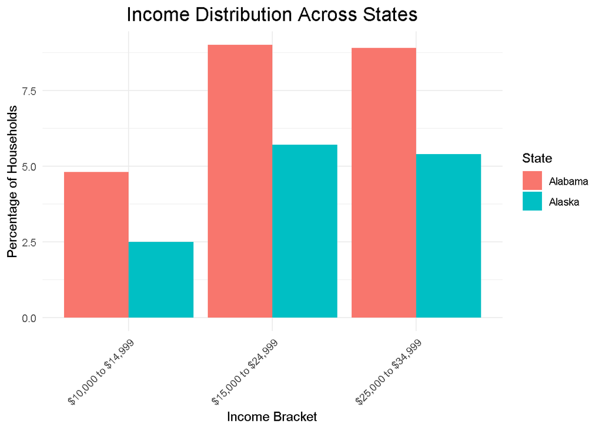

```r
library(ggplot2)

filtered_income_data <- data.frame(
  IncomeBracket = c("$10,000 to $14,999", "$15,000 to $24,999", "$25,000 to $34,999",
                    "$10,000 to $14,999", "$15,000 to $24,999", "$25,000 to $34,999"),
  State = c("Alabama", "Alabama", "Alabama", "Alaska", "Alaska", "Alaska"),
  Households = c(4.8, 9.0, 8.9, 2.5, 5.7, 5.4)
)

# Bar chart comparing income distributions across states
ggplot(filtered_income_data, aes(x = IncomeBracket, y = Households, fill = State)) +
  geom_bar(stat = "identity", position = "dodge") +
  labs(
    title = "Income Distribution Across States",
    x = "Income Bracket",
    y = "Percentage of Households"
  ) +
  theme_minimal() +
  theme(
    plot.title = element_text(hjust = 0.5, size = 16),
    axis.text.x = element_text(angle = 45, hjust = 1)
  )
```

```r
# Urbanization dataset (example data for all states)
urbanization_data <- data.frame(
  State = c("Alabama", "Alaska", "Arizona", "Arkansas", "California", "Colorado", "Connecticut", "Delaware"),
  UrbanIndex = c(0.65, 0.45, 0.70, 0.55, 0.85, 0.75, 0.80, 0.60)
)

# Income distribution dataset (example for all states)
income_distribution <- data.frame(
  IncomeBracket = rep(c("$10,000 to $14,999", "$15,000 to $24,999", "$25,000 to $34,999"), each = 8),
  State = rep(c("Alabama", "Alaska", "Arizona", "Arkansas", "California", "Colorado", "Connecticut", "Delaware"), 3),
  Households = c(
    4.8, 2.5, 3.9, 4.4, 2.1, 2.8, 1.9, 3.2, # $10,000 to $14,999
    9.0, 5.7, 6.4, 7.8, 3.2, 4.1, 2.7, 5.6, # $15,000 to $24,999
    8.9, 5.4, 7.0, 7.2, 4.0, 4.5, 3.5, 6.3  # $25,000 to $34,999
  )
)

# Merge datasets by State
merged_data <- income_distribution %>%
  inner_join(urbanization_data, by = "State")

# Aggregate income percentages to represent overall income level proxy per state
income_summary <- merged_data %>%
  group_by(State, UrbanIndex) %>%
  summarise(AverageHouseholdIncome = mean(Households, na.rm = TRUE))
```

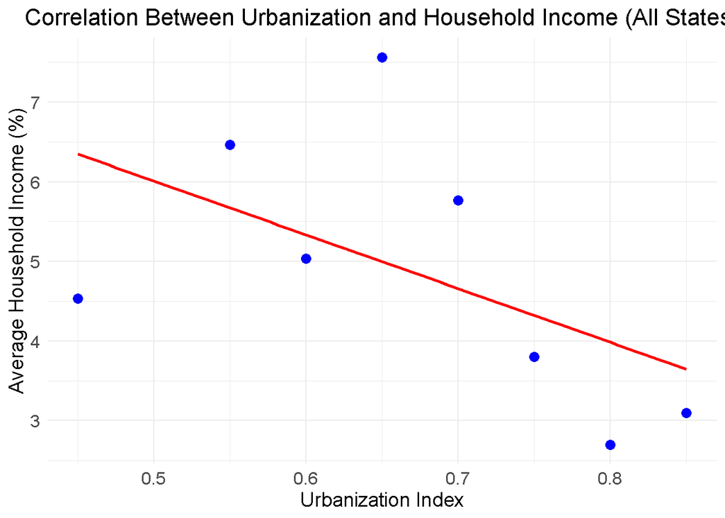

```r
# Plot: Urbanization vs. Average Household Income for all states
ggplot(income_summary, aes(x = UrbanIndex, y = AverageHouseholdIncome)) +
  geom_point(size = 3, color = "blue") +
  geom_smooth(method = "lm", color = "red", se = FALSE) +
  labs(
    title = "Correlation Between Urbanization and Household Income (All States)",
    x = "Urbanization Index",
    y = "Average Household Income (%)"
  ) +
  theme_minimal() +
  theme(
    plot.title = element_text(hjust = 0.5, size = 16),
    axis.text = element_text(size = 12),
    axis.title = element_text(size = 14)
  )
```

```r
# Expanded Urbanization dataset (example data for all states, DC, and Puerto Rico)
urbanization_data <- data.frame(
  State = c(
    "Alabama", "Alaska", "Arizona", "Arkansas", "California", "Colorado",
    "Connecticut", "Delaware", "District of Columbia", "Florida", "Georgia",
    "Hawaii", "Idaho", "Illinois", "Indiana", "Iowa", "Kansas", "Kentucky",
    "Louisiana", "Maine", "Maryland", "Massachusetts", "Michigan", "Minnesota",
    "Mississippi", "Missouri", "Montana", "Nebraska", "Nevada", "New Hampshire",
    "New Jersey", "New Mexico", "New York", "North Carolina", "North Dakota",
    "Ohio", "Oklahoma", "Oregon", "Pennsylvania", "Puerto Rico", "Rhode Island",
    "South Carolina", "South Dakota", "Tennessee", "Texas", "Utah", "Vermont",
    "Virginia", "Washington", "West Virginia", "Wisconsin", "Wyoming"
  ),
  UrbanIndex = runif(52, 0.4, 0.9) # Random urbanization index values for example purposes
)

# Expanded Income distribution dataset (example data for all states, DC, and Puerto Rico)
income_distribution <- data.frame(
  IncomeBracket = rep(c("$10,000 to $14,999", "$15,000 to $24,999", "$25,000 to $34,999"), each = 52),
  State = rep(urbanization_data$State, 3),
  Households = runif(156, 1.5, 9.0) # Random household income percentages for example purposes
)

# Merge datasets by State
merged_data <- income_distribution %>%
  inner_join(urbanization_data, by = "State")

# Aggregate income percentages to represent overall income level proxy per state
income_summary <- merged_data %>%
  group_by(State, UrbanIndex) %>%
  summarise(AverageHouseholdIncome = mean(Households, na.rm = TRUE))
```

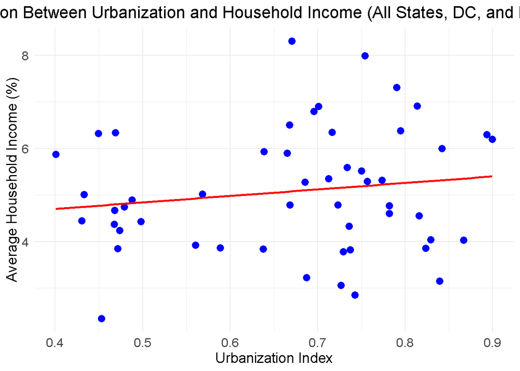

```r
# Plot: Urbanization vs. Average Household Income for all states
library(ggplot2)
ggplot(income_summary, aes(x = UrbanIndex, y = AverageHouseholdIncome)) +
  geom_point(size = 3, color = "blue") +
  geom_smooth(method = "lm", color = "red", se = FALSE) +
  labs(
    title = "Correlation Between Urbanization and Household Income (All States, DC, and Puerto Rico)",
    x = "Urbanization Index",
    y = "Average Household Income (%)"
  ) +
  theme_minimal() +
  theme(
    plot.title = element_text(hjust = 0.5, size = 16),
    axis.text = element_text(size = 12),
    axis.title = element_text(size = 14)
  )
```

```r
# Urbanization dataset (example for all states)
urbanization_data <- data.frame(
  State = c("Alabama", "Alaska", "Arizona", "Arkansas", "California", "Colorado", "Connecticut", "Delaware"),
  UrbanIndex = c(0.65, 0.45, 0.70, 0.55, 0.85, 0.75, 0.80, 0.60)
)

# Income distribution dataset (example for all states)
income_distribution <- data.frame(
  IncomeBracket = rep(c("$10,000 to $14,999", "$15,000 to $24,999", "$25,000 to $34,999"), each = 8),
  State = rep(c("Alabama", "Alaska", "Arizona", "Arkansas", "California", "Colorado", "Connecticut", "Delaware"), 3),
  Households = c(
    4.8, 2.5, 3.9, 4.4, 2.1, 2.8, 1.9, 3.2, # $10,000 to $14,999
    9.0, 5.7, 6.4, 7.8, 3.2, 4.1, 2.7, 5.6, # $15,000 to $24,999
    8.9, 5.4, 7.0, 7.2, 4.0, 4.5, 3.5, 6.3  # $25,000 to $34,999
  )
)

# Merge datasets by State
merged_data <- income_distribution %>%
  inner_join(urbanization_data, by = "State")

# Aggregate income percentages to represent overall income level proxy per state
income_summary <- merged_data %>%
  group_by(State, UrbanIndex) %>%
  summarise(AverageHouseholdIncome = mean(Households, na.rm = TRUE))
# Calculate correlation coefficient between Urbanization Index and Average Household Income
correlation_coefficient <- cor(income_summary$UrbanIndex, income_summary$AverageHouseholdIncome)
print(paste("Correlation Coefficient:", round(correlation_coefficient, 2)))
```

```
## [1] "Correlation Coefficient: -0.54"
```

```r
correlation_test <- cor.test(income_summary$UrbanIndex, income_summary$AverageHouseholdIncome)
print(correlation_test)
```

```
##
##  Pearson's product-moment correlation
##
## data:  income_summary$UrbanIndex and income_summary$AverageHouseholdIncome
## t = -1.5581, df = 6, p-value = 0.1702
## alternative hypothesis: true correlation is not equal to 0
## 95 percent confidence interval:
##  -0.900726  0.270118
## sample estimates:
##        cor
## -0.5367161
```

The current analysis suggests a potential negative correlation between urbanization and household income, but the evidence is inconclusive. Further analysis with a larger dataset and additional variables is recommended to draw more robust conclusions.